# Lab 05 - Data Wrangling

# Learning goals

- Use the `merge()` function to join two datasets.
- Deal with missings and impute data.
- Identify relevant observations using `quantile()`.
- Practice your GitHub skills.

# Lab description

For this lab we will be dealing with the meteorological dataset `met`. In this case, we will use `data.table` to answer some questions regarding the `met` dataset, while at the same time practice your Git+GitHub skills for this project.

This markdown document should be rendered using `github_document` document.

# Part 1: Setup a Git project and the GitHub repository

1. Go to wherever you are planning to store the data on your computer, and create a folder for this project
2. In that folder, save [this template](https://github.com/JSC370/JSC370-2025/blob/main/labs/lab05/lab05-wrangling-gam.Rmd) as “README.Rmd”. This will be the markdown file where all the magic will happen.
3. Go to your GitHub account and create a new repository of the same name that your local folder has, e.g., “JSC370-labs”.
4. Initialize the Git project, add the “README.Rmd” file, and make your first commit.
5. Add the repo you just created on GitHub.com to the list of remotes, and push your commit to origin while setting the upstream.

Most of the steps can be done using command line:

```bash
# Step 1
cd ~/Documents
mkdir JSC370-labs
cd JSC370-labs

# Step 2
wget https://raw.githubusercontent.com/JSC370/jsc370-2023/main/labs/lab05/lab05-wrangling-gam.Rmd
mv lab05-wrangling-gam.Rmd README.Rmd
# if wget is not available,
curl https://raw.githubusercontent.com/JSC370/jsc370-2023/main/labs/lab05/lab05-wrangling-gam.Rmd --output README.Rmd

# Step 3
# Happens on github

# Step 4
git init
git add README.Rmd
git commit -m "First commit"

# Step 5
git remote add origin git@github.com:[username]/JSC370-labs
git push -u origin master
```

You can also complete the steps in R (replace with your paths/username when needed)

```r
# Step 1
setwd("~/Documents")
dir.create("JSC370-labs")
setwd("JSC370-labs")

# Step 2
download.file(
  "https://raw.githubusercontent.com/JSC370/jsc370-2023/main/labs/lab05/lab05-wrangling-gam.Rmd",
  destfile = "README.Rmd"
  )

# Step 3: Happens on Github

# Step 4
system("git init && git add README.Rmd")
system('git commit -m "First commit"')

# Step 5
system("git remote add origin git@github.com:[username]/JSC370-labs")
system("git push -u origin master")
```

Once you are done setting up the project, you can now start working with the MET data.

## Setup in R

1. Load the `data.table` (and the `dtplyr` and `dplyr` packages).

```r
library(tidyverse)
library(dplyr)
library(dtplyr)
library(mgcv)
library(leaflet)
library(data.table)
library(kableExtra)
```

2. Load the met data from https://raw.githubusercontent.com/JSC370/JSC370-2024/main/data/met_all_2023.gz, and also the station data. For the latter, you can use the code we used during lecture to pre-process the stations data:

```r
# Download the data
stations <- fread("ftp://ftp.ncdc.noaa.gov/pub/data/noaa/isd-history.csv")
stations[, USAF := as.integer(USAF)]
# Dealing with NAs and 999999
stations[, USAF   := fifelse(USAF == 999999, NA_integer_, USAF)]
stations[, CTRY   := fifelse(CTRY == "", NA_character_, CTRY)]
stations[, STATE  := fifelse(STATE == "", NA_character_, STATE)]

# Selecting the three relevant columns, and keeping unique records
stations <- unique(stations[, list(USAF, CTRY, STATE)])

# Dropping NAs
stations <- stations[!is.na(USAF)]

# Removing duplicates
stations[, n := 1:.N, by = .(USAF)]
stations <- stations[n == 1,][, n := NULL]
```

```r
# Read in the met data
url <- "https://raw.githubusercontent.com/JSC370/JSC370-2025/main/data/met/met_all.gz"
local_path <- "met_all.gz"
if (!file.exists(local_path)) {
    tryCatch({
      download.file(url,
        destfile = local_path,
        method   = "curl",
        timeout  = 60
  )
      cat("File downloaded and saved at:", local_path, "\n")
  }, error = function(e) {
      cat("Error downloading file:", e$message, "\n")
  })
} else {
      cat("File already exists at:", local_path, "\n")
}
```

```
## File already exists at: met_all.gz
```

```r
met <- fread("./met_all.gz") # if downloaded locally
```

3. Merge the data as we did during the lecture. Use the `merge()` code and you can also try the tidy way with `left_join()`

```r
joined <- left_join(x = met,
                    y =  stations,
                    by = c("USAFID" = "USAF"))
```

## Question 1: Representative station for the US

Across all weather stations, what stations have the median values of temperature, wind speed, and atmospheric pressure? Using the `quantile()` function, identify these three stations. Do they coincide?

```r
true_med <- joined[, .(
  temp_50 = quantile(temp, probs=0.5, na.rm=TRUE),
  wind.sp_50 = quantile(wind.sp, probs=0.5, na.rm=TRUE),
  atm.press_50 = quantile(atm.press, probs=0.5, na.rm=TRUE)
)]
station_med <- joined[, .(
  temp = quantile(temp, probs=0.5, na.rm=TRUE),
  wind.sp = quantile(wind.sp, probs=0.5, na.rm=TRUE),
  atm.press = quantile(atm.press, probs=0.5, na.rm=TRUE)
), by = .(USAFID, STATE)]
true_med
```

```
##    temp_50 wind.sp_50 atm.press_50
##      <num>      <num>        <num>
## 1:    23.5        2.1       1014.1
```

```r
station_med
```

```
##       USAFID  STATE  temp wind.sp atm.press
##        <int> <char> <num>   <num>     <num>
##    1: 690150     CA  32.8     3.1   1010.50
##    2: 720110     TX  31.0     2.1        NA
##    3: 720113     MI  23.2     2.6        NA
##    4: 720120     SC  27.0     2.6        NA
##    5: 720137     IL  22.0     1.5        NA
##   ---
## 1591: 726777     MT  18.3     4.6   1014.30
## 1592: 726797     MT  18.3     2.6   1015.20
## 1593: 726798     MT  19.0     4.1   1014.30
## 1594: 726810     ID  25.0     3.1   1011.10
## 1595: 726813     ID  22.8     2.1   1011.75
```

```r
station_med[, temp_dist := abs(temp - true_med$temp_50)] |> head()
```

```
##    USAFID  STATE  temp wind.sp atm.press temp_dist
##     <int> <char> <num>   <num>     <num>     <num>
## 1: 690150     CA  32.8     3.1    1010.5       9.3
## 2: 720110     TX  31.0     2.1        NA       7.5
## 3: 720113     MI  23.2     2.6        NA       0.3
## 4: 720120     SC  27.0     2.6        NA       3.5
## 5: 720137     IL  22.0     1.5        NA       1.5
## 6: 720151     TX  27.1     3.1        NA       3.6
```

```r
med_temp_station <- station_med[temp_dist == 0]
station_med[, wind.sp_dist := abs(wind.sp - true_med$wind.sp_50)] |> head()
```

```
##    USAFID  STATE  temp wind.sp atm.press temp_dist wind.sp_dist
##     <int> <char> <num>   <num>     <num>     <num>        <num>
## 1: 690150     CA  32.8     3.1    1010.5       9.3          1.0
## 2: 720110     TX  31.0     2.1        NA       7.5          0.0
## 3: 720113     MI  23.2     2.6        NA       0.3          0.5
## 4: 720120     SC  27.0     2.6        NA       3.5          0.5
## 5: 720137     IL  22.0     1.5        NA       1.5          0.6
## 6: 720151     TX  27.1     3.1        NA       3.6          1.0
```

```r
med_wind.sp_station <- station_med[wind.sp_dist == 0]
station_med[, atm.press_dist := abs(atm.press - true_med$atm.press_50)] |> head()
```

```
##    USAFID  STATE  temp wind.sp atm.press temp_dist wind.sp_dist atm.press_dist
##     <int> <char> <num>   <num>     <num>     <num>        <num>          <num>
## 1: 690150     CA  32.8     3.1    1010.5       9.3          1.0            3.6
## 2: 720110     TX  31.0     2.1        NA       7.5          0.0             NA
## 3: 720113     MI  23.2     2.6        NA       0.3          0.5             NA
## 4: 720120     SC  27.0     2.6        NA       3.5          0.5             NA
## 5: 720137     IL  22.0     1.5        NA       1.5          0.6             NA
## 6: 720151     TX  27.1     3.1        NA       3.6          1.0             NA
```

```r
med_atm.press_station <- station_med[atm.press_dist == 0]

print(med_temp_station, med_wind.sp_station, med_atm.press_station)
```

```
##    USAFID  STATE  temp wind.sp atm.press temp_dist
##     <int> <char> <num>   <num>     <num>     <num>
## 1: 720501     VA  23.5     1.5        NA         0
## 2: 722031     AL  23.5     0.0        NA         0
## 3: 722148     NC  23.5     0.0        NA         0
## 4: 723055     NC  23.5     0.0        NA         0
## 5: 723067     NC  23.5     1.5        NA         0
## 6: 723177     NC  23.5     0.0        NA         0
## 7: 725564     NE  23.5     2.6        NA         0
```

Knit the document, commit your changes, and save it on GitHub. Don’t forget to add `README.md` to the tree, the first time you render it.

## Question 2: Representative station per state

Just like the previous question, you are asked to identify what is the most representative, the median, station per state. This time, instead of looking at one variable at a time, look at the euclidean distance. If multiple stations show in the median, select the one located at the lowest latitude.

```r
station_med[, temp_50 := quantile(temp, probs=0.5, na.rm=TRUE), by=STATE]
station_med[, wind.sp_50 := quantile(wind.sp, probs=0.5, na.rm=TRUE), by=STATE]

station_med[, eudist := sqrt(
  (temp-temp_50)^2 + (wind.sp-wind.sp_50)^2
)]
station_med
```

```
## Indices: <temp_dist>, <wind.sp_dist>, <atm.press_dist>
##       USAFID  STATE  temp wind.sp atm.press temp_dist wind.sp_dist
##        <int> <char> <num>   <num>     <num>     <num>        <num>
##    1: 690150     CA  32.8     3.1   1010.50       9.3          1.0
##    2: 720110     TX  31.0     2.1        NA       7.5          0.0
##    3: 720113     MI  23.2     2.6        NA       0.3          0.5
##    4: 720120     SC  27.0     2.6        NA       3.5          0.5
##    5: 720137     IL  22.0     1.5        NA       1.5          0.6
##   ---
## 1591: 726777     MT  18.3     4.6   1014.30       5.2          2.5
## 1592: 726797     MT  18.3     2.6   1015.20       5.2          0.5
## 1593: 726798     MT  19.0     4.1   1014.30       4.5          2.0
## 1594: 726810     ID  25.0     3.1   1011.10       1.5          1.0
## 1595: 726813     ID  22.8     2.1   1011.75       0.7          0.0
##       atm.press_dist temp_50 wind.sp_50     eudist
##                <num>   <num>      <num>      <num>
##    1:           3.60   21.70       2.60 11.1112556
##    2:             NA   29.05       3.10  2.1914607
##    3:             NA   20.70       2.10  2.5495098
##    4:             NA   25.00       1.50  2.2825424
##    5:             NA   22.20       2.10  0.6324555
##   ---
## 1591:           0.20   18.30       3.60  1.0000000
## 1592:           1.10   18.30       3.60  1.0000000
## 1593:           0.20   18.30       3.60  0.8602325
## 1594:           3.00   19.70       2.35  5.3528030
## 1595:           2.35   19.70       2.35  3.1100643
```

```r
id_station <- station_med[, .SD[which.min(eudist)], by=STATE]
id_station <- left_join(x=id_station,
                        y=stations,
                        by = c('USAFID' = 'USAF', 'STATE'))
id_station
```

```
##      STATE USAFID  temp wind.sp atm.press temp_dist wind.sp_dist atm.press_dist
##     <char>  <int> <num>   <num>     <num>     <num>        <num>          <num>
##  1:     CA 722880 22.20     2.6   1011.80      1.30          0.5           2.30
##  2:     TX 723628 29.00     3.1        NA      5.50          1.0             NA
##  3:     MI 725395 20.60     2.1   1014.55      2.90          0.0           0.45
##  4:     SC 720596 25.00     1.5        NA      1.50          0.6             NA
##  5:     IL 722076 22.20     2.1        NA      1.30          0.0             NA
##  6:     MO 720479 23.00     2.6        NA      0.50          0.5             NA
##  7:     AR 723407 25.00     2.1   1014.50      1.50          0.0           0.40
##  8:     OR 720202 17.00     1.5        NA      6.50          0.6             NA
##  9:     WA 720388 18.00     0.0        NA      5.50          2.1             NA
## 10:     GA 722166 25.60     1.5   1015.65      2.10          0.6           1.55
## 11:     MN 720386 20.00     2.6        NA      3.50          0.5             NA
## 12:     AL 722238 25.00     1.5   1014.50      1.50          0.6           0.40
## 13:     IN 724365 22.20     2.1   1015.30      1.30          0.0           1.20
```

[output cut: 87 more lines]

Knit the doc and save it on GitHub.

## Question 3: In the middle?

For each state, identify what is the station that is closest to the mid-point of the state. Combining these with the stations you identified in the previous question, use `leaflet()` to visualize all ~100 points in the same figure, applying different colors for those identified in this question.

```r
midpoint <- joined[, .(
  lat50 = quantile(lat, probs=0.5, na.rm=TRUE),
  lon50 = quantile(lon, probs=0.5, na.rm=TRUE)
), by=.(STATE)]

mid <- merge(x=joined, y=midpoint, by='STATE')

mid[, mid_eudist := sqrt(
  (lat - lat50)^2 + (lon - lon50)^2
)]

mid_station <- mid[, .SD[which.min(mid_eudist)], by='STATE']
```

```r
to_plot <- left_join(id_station, met, by='USAFID')
leaflet() |>
    addProviderTiles("OpenStreetMap") |>
    addCircles(data=mid_station,lat = ~lat, lng = ~lon,
               opacity = 1, fillOpacity = 1, radius = 400, color='blue') |>
    addCircles(data=to_plot,lat = ~lat, lng = ~lon,
               opacity = 1, fillOpacity = 1, radius = 400, color='magenta')
```

[interactive chart not shown]

Knit the doc and save it on GitHub.

## Question 4: Means of means

Using the `quantile()` function, generate a summary table that shows the number of states included, average temperature, wind-speed, and atmospheric pressure by the variable “average temperature level,” which you’ll need to create.

Start by computing the states’ average temperature. Use that measurement to classify them according to the following criteria:

- low: temp < 20
- Mid: temp >= 20 and temp < 25
- High: temp >= 25

```r
tmp <- joined |>
  group_by(STATE) |>
  summarize(temp_mean = mean(temp, na.rm=TRUE)) |>
  mutate(avg_temp_level = case_when(
           temp_mean < 20 ~ 'low',
           20 <= temp_mean & temp_mean < 25 ~ 'medium',
           25 <= temp_mean ~ 'high'
         ))
```

Once you are done with that, you can compute the following:

- Number of entries (records),
- Number of NA entries,
- Number of stations,
- Number of states included, and
- Mean temperature, wind-speed, and atmospheric pressure.

All by the levels described before.

```r
summary_tbl <- merge(x=joined, y=tmp, by='STATE') |>
  group_by(avg_temp_level) |>
  summarize(
    num_entries=n(),
    num_na=sum(is.na(temp)) + sum(is.na(wind.sp)) + sum(is.na(atm.press)),
    num_stations=n_distinct(USAFID),
    num_states=n_distinct(STATE),
    mean_temp=mean(temp, na.rm=T),
    mean_wind.sp=mean(wind.sp, na.rm=T),
    mean_atm.press=mean(atm.press, na.rm=T)
            )
kable(summary_tbl, booktabs=TRUE) |>
  kable_styling(font_size=10) |>
  kable_paper("hover", full_width=F)
```

| avg_temp_level | num_entries | num_na | num_stations | num_states | mean_temp | mean_wind.sp | mean_atm.press |
| --- | --- | --- | --- | --- | --- | --- | --- |
| high | 811126 | 625973 | 555 | 12 | 27.75066 | 2.514644 | 1013.738 |
| low | 430794 | 360626 | 259 | 11 | 18.96446 | 2.637410 | 1014.366 |
| medium | 1135423 | 819457 | 781 | 25 | 22.39909 | 2.352712 | 1014.383 |

Knit the document, commit your changes, and push them to GitHub.

## Question 5: Advanced Regression

Let’s practice running regression models with smooth functions on X. We need the `mgcv` package and `gam()` function to do this.

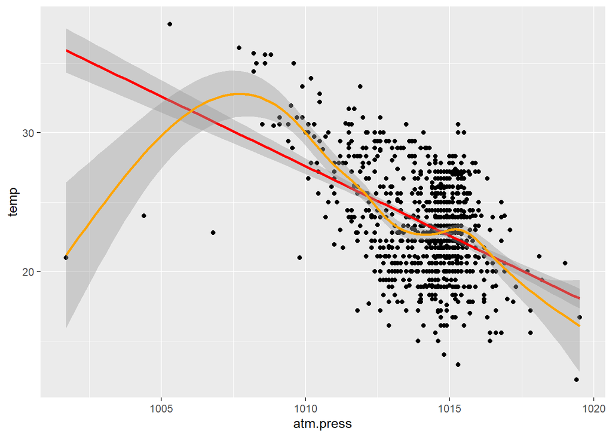

```r
station_med_lt <- lazy_dt(station_med) |>
  filter(between(atm.press, 1000, 1020)) |>
  collect()

ggplot(station_med_lt, aes(x=atm.press, y=temp)) +
  geom_point() +
  geom_smooth(method='lm', col='red') +
  geom_smooth(method='gam', col='orange')
```

```r
lmod <- lm(temp~atm.press, data=station_med_lt)
summary(lmod)
```

```
##
## Call:
## lm(formula = temp ~ atm.press, data = station_med_lt)
##
## Residuals:
##     Min      1Q  Median      3Q     Max
## -14.928  -2.390   0.044   2.525   8.323
##
## Coefficients:
##               Estimate Std. Error t value Pr(>|t|)
## (Intercept) 1041.37307   65.49707   15.90   <2e-16 ***
## atm.press     -1.00374    0.06459  -15.54   <2e-16 ***
## ---
## Signif. codes:  0 '***' 0.001 '**' 0.01 '*' 0.05 '.' 0.1 ' ' 1
##
## Residual standard error: 3.33 on 898 degrees of freedom
## Multiple R-squared:  0.212,  Adjusted R-squared:  0.2111
## F-statistic: 241.5 on 1 and 898 DF,  p-value: < 2.2e-16
```

```r
gamod <- gam(temp~s(atm.press, bs='cr', k=20), data=station_med_lt)
summary(gamod)
```

```
##
## Family: gaussian
## Link function: identity
##
## Formula:
## temp ~ s(atm.press, bs = "cr", k = 20)
##
## Parametric coefficients:
##             Estimate Std. Error t value Pr(>|t|)
## (Intercept)  23.4852     0.1051   223.4   <2e-16 ***
## ---
## Signif. codes:  0 '***' 0.001 '**' 0.01 '*' 0.05 '.' 0.1 ' ' 1
##
## Approximate significance of smooth terms:
##                edf Ref.df     F p-value
## s(atm.press) 9.861  11.83 31.76  <2e-16 ***
## ---
## Signif. codes:  0 '***' 0.001 '**' 0.01 '*' 0.05 '.' 0.1 ' ' 1
##
## R-sq.(adj) =  0.293   Deviance explained = 30.1%
## GCV = 10.064  Scale est. = 9.9425    n = 900
```

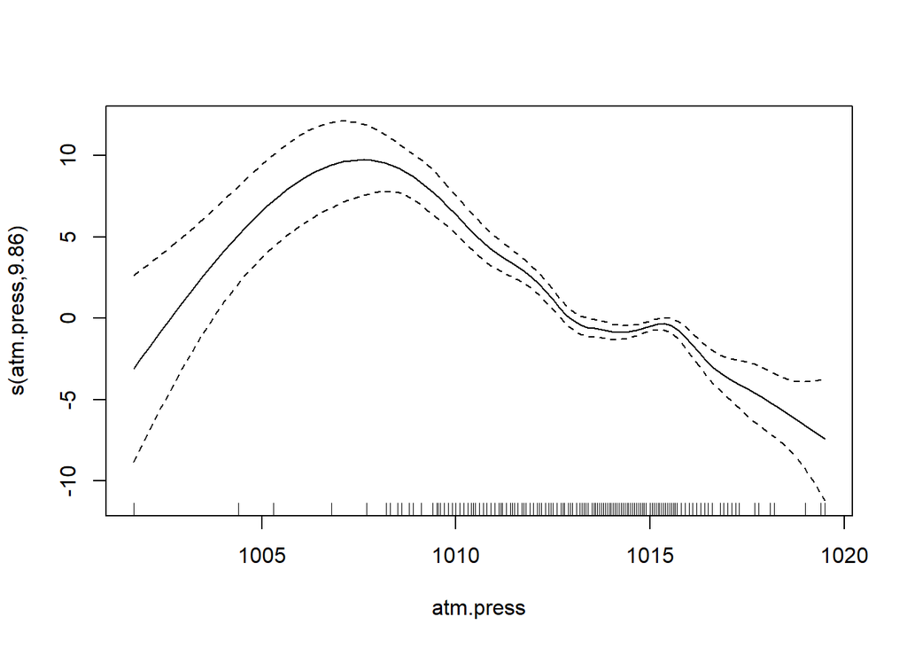

```r
plot(gamod)
```